# Time Series

**Time series analysis**: A statistical approach that deals with data collected over time. It is widely used in various fields, including - finance and economics - engineering, and - environmental science.

The data is typically expressed as $\{Y_t\}_{t=0}^T = \{Y_0,Y_1,\cdots,Y_T\}$

- We will assume the observations are evenly spaced in time
- We will assume an additive linear form for the distribution of the time series as

$$Y_t = \beta_0 + \sum_{s=0}^{t-1}\beta_sY_s + \sum_{s=0}^{t-1} \theta_s \epsilon_s + \epsilon_t$$

where $\{\epsilon_s\}_{s=0}^{t-1}$ are random errors, or *white noise* terms. This model allows for correlation of the random variable $Y_t$ with

- Past white noise terms (deviations from the mean)
- Past data observations

**Stationarity**: A time series is **stationary** if its statistical properties (e.g., mean, variance) do not change over time. Stationarity is essential for many time series models because it allows us to make valid predictions.

### Example of a Non-stationary Process

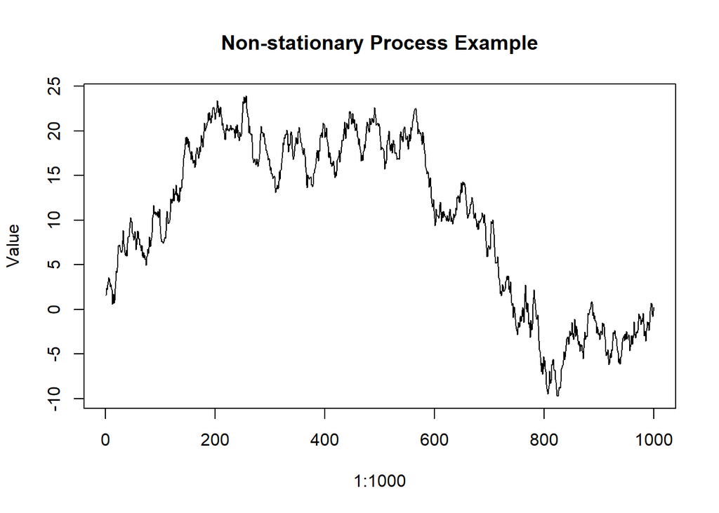

### Examples of a Stationary Process

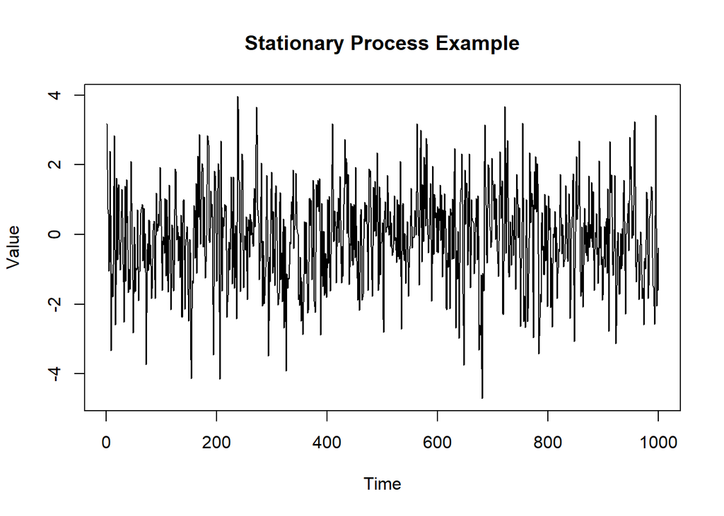

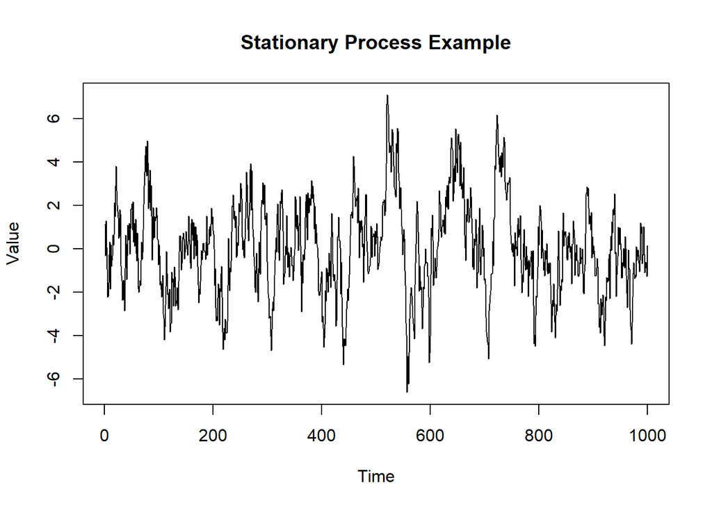

- One reason we may not be able to model a non-stationary process is that as $t \rightarrow \infty$, it may be true that $E(Y_t) \rightarrow \infty$ and $\text{Var}(Y_t) \rightarrow \infty$

## Types of Stationarity

**First-Order Stationarity**: The mean of $Y_t$ is constant at each time point

$$E(Y_s) = E(Y_t) \text{ for } 0 \leq s \leq t \leq T$$
**Second-Order Stationarity**: The covariance of $Y_t$ and $Y_{t+h}$ for some lag $h$ is constant at each time point

$$\text{Cov}(Y_s,Y_{s+h}) = \text{Cov}(Y_t,Y_{t+h}) \text{ for } 0 \leq s \leq t \leq T$$
- **Note**: This implies that $\text{Var}(Y_s) = \text{Var}(Y_t)$

Both of the above types of stationarity are considered to be **weak stationarity**

**Strict Stationarity**: The joint distribution of any set of points does not change over time. For some lag $h > 0$

$$f(Y_{s},Y_{s+1},\cdots,Y_{s+h}) = f(Y_{t},Y_{t+1},\cdots,Y_{t+h}) \text{ for } 0 \leq s \leq t \leq T$$
**Autocorrelation**: the degree of correlation of the same variables between two successive time intervals

- *Lag 1 Autocorrelation*: $\text{Cor}(Y_s,Y_{s+1})$ for $s = 0,\cdots,T-1$
- *Lag 2 Autocorrelation*: $\text{Cor}(Y_s,Y_{s+2})$ for $s = 0,\cdots,T-2$
- *Lag 3 Autocorrelation*: $\text{Cor}(Y_s,Y_{s+3})$ for $s = 0,\cdots,T-3$
- etc.

Let’s visualize what autocorrelation looks like for the non-stationary and stationary time series

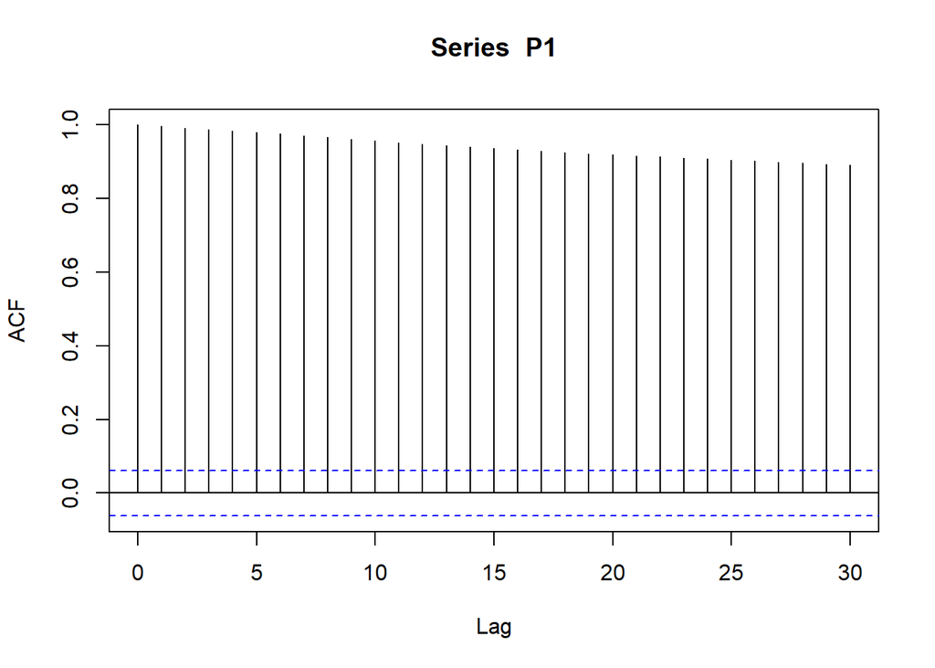

```r
# P1 is the non-stationary time series
# ma_data is a stationary time series
# acf is a function that plots the autocorrelation of a time series
acf(P1)
```

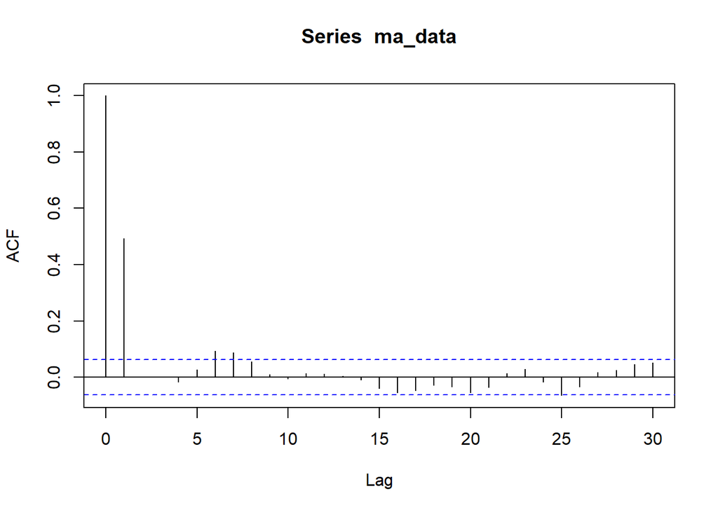

```r
acf(ma_data)
```

**Moving Average (MA)**: time series model that expresses the output as a linear function of past white noise terms.

- MA model of order $q$:
  $$Y_t = \mu + \epsilon_t + \theta_1\epsilon_{t-1} + \theta_2\epsilon_{t-2} + \cdots + \theta_q\epsilon_{t-q}$$

$\epsilon_{t-h} = Y_{t-h} - \mu$ for $h = 1,\dots,q$

$\epsilon_t \sim \mathcal{N}(0,\sigma^2)$

- $\theta_h: h = 1,\cdots,q$ are moving average regression parameters in our model

*Notes*:

- MA models should be used in time series that are heavily influenced by random shocks whose influence dissipates over time
- MA models are always strictly stationary! (Assuming the white noise terms are independent)

**Partial Autocorrelation**: the partial correlation of a stationary time series with its own lagged values, regressed the values of the time series at all shorter lags

- This contrasts with the autocorrelation function, which does not take into account the lagged values

Let’s visualize what partial autocorrelation looks like for the non-stationary and stationary time series

- In other words, what is the autocorrelation structure after taking into account all of the previous autocorrelations (including its own)

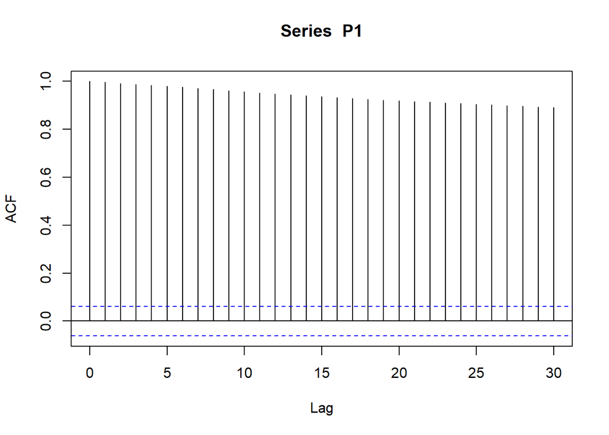

```r
acf(P1)
```

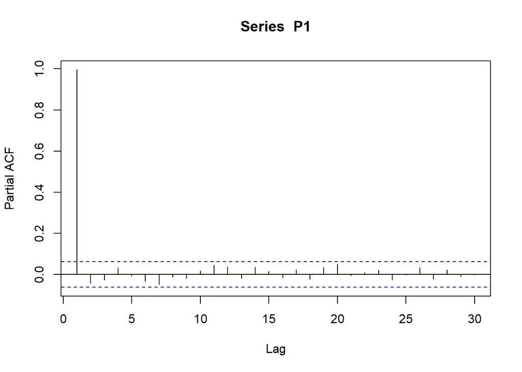

```r
pacf(P1)
```

[figure not shown]

```r
acf(ma_data)
acf(ma_data)
```

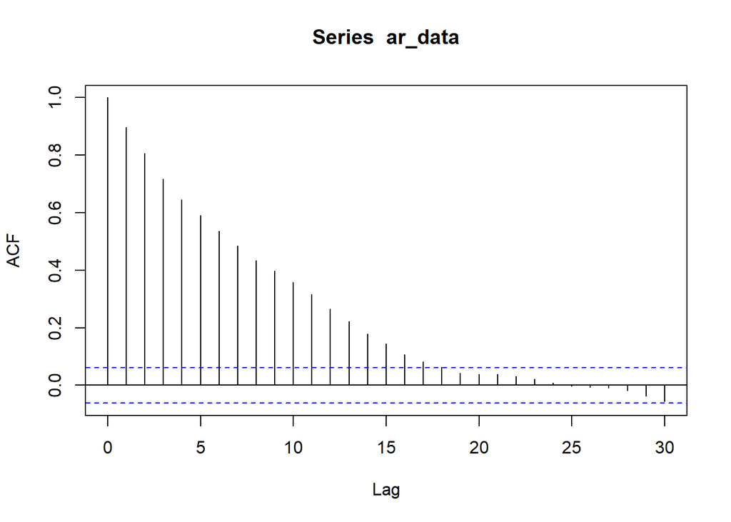

```r
acf(ar_data)
```

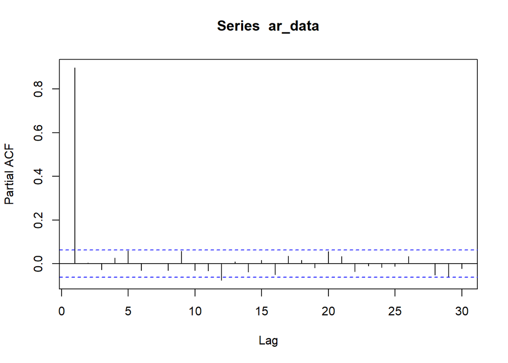

```r
pacf(ar_data)
```

**Autoregressive (AR)**: time series model that expresses the output as a linear function of past observed values.

- AR model of order $p$:
  $$Y_t = \mu + \beta_1Y_{t-1} + \beta_2Y_{t-2} + \cdots + \beta_pY_{t-p} + \epsilon_t$$

$\beta_i: i = 1,\dots,p$ are AR regression parameters

$\epsilon_t \sim \mathcal{N}(0,\sigma^2)$

- Essentially this is a linear regression model where the previous observations are the explanatory variables

*Notes*:

**Augmented Dickey-Fuller (ADF) Test**: A statistical test to determine if a time series is stationary. The overall test assumes that the data follows an AR(1) model, i.e.

$$Y_t = \mu + \beta_1 Y_{t-1} + \epsilon_t$$
$$H_0: |\beta_1| \geq 1 (\text{Not stationary})$$
$$H_a: |\beta_1| < 1 (\text{Stationary})$$

```r
library(tseries)
adf.test(P1) # pvalue > 0.05, not enough evidence the data is stationary
```

```
    Augmented Dickey-Fuller Test

data:  P1
Dickey-Fuller = -2.6782, Lag order = 9, p-value = 0.2912
alternative hypothesis: stationary
```

```r
adf.test(ma_data) # pvalue < 0.05, enough evidence the data is stationary
```

```
    Augmented Dickey-Fuller Test

data:  ma_data
Dickey-Fuller = -8.8518, Lag order = 9, p-value = 0.01
alternative hypothesis: stationary
```

```r
adf.test(ar_data) # pvalue < 0.05, enough evidence the data is stationary
```

```
    Augmented Dickey-Fuller Test

data:  ar_data
Dickey-Fuller = -5.8602, Lag order = 9, p-value = 0.01
alternative hypothesis: stationary
```

**ARMA Model**: A model that combines moving average and autoregressive models

ARMA model of order $(p,q)$:

$$Y_t = \mu + \sum_{s=1}^{p}\beta_sY_{t-s} + \sum_{s=1}^{q} \theta_s \epsilon_{t-s} + \epsilon_t$$
where $p$ and $q$ are the orders of the autoregressive and moving average terms in the model, respectively.

*Note*: The ARMA model only works for stationary time series.

### Interactive Example

Simulate an ARMA(1,1) dataset and fit the model to a variety of different ARMA models

### Example

Consider the AirPassengers dataset in R, which contains information about monthly number of airline passengers (in thousands) from January 1949 to December 1960, for a total of 144 observations

(a). Plot the air passengers dataset. Determine any trends you see in the model.

(b). Determine if the data is non-stationary.

(c). Create a best-fitting ARMA model for the dataset.